# eQTL Analysis for Monoculture

# eQTL analysis Script (Walkthrough)

## Step1: ### Load the required Libraries to perform eQTL analysis

One first needs to install the following packages before loading the libraries. Packages can be installed using install.packages(“**library name**”)

```r
#Load required libraries for eQTL analysis

library(readr)
library(tidyr)
library(dplyr)
library("devtools")
#install_github("kassambara/factoextra")
library("factoextra")
library(MASS)
library(ggplot2)
library(factoextra)
library(MatrixEQTL)
suppressMessages(library(MatrixEQTL))
library(dplyr)
```

## Step2: Filter SNPs (genotypes) based on Minor Allele Frequecy (MAF) score and obtain covariates of SNP data by calculating Principal components from the PCA analysis.

Before starting the analysis, we removed 4 out of 96 isolates based on the Genotype Similarity and Dissimilarity scores between the SNP derived from the Transcriptomic and Genomic data. So we have SNP infomation from 92 isolates for both Monocultures and Cocultures. SNP data contains the isolates IDs as the row names and SNP genotype information as column names. It is Huge matrix of 92 rows and 282232 columns

### Read genotype file and save it in the ‘gt’ dataframe

```r
gt = read.table("Desktop/Abhilash/study/Post-Doc/Lab_notebook/eQTL/Input_3/Differential_regulation_files/eQTL_input/MATRIX_eQTL/whole_genome/input/snps_Allchr.txt", sep="\t",
                header=TRUE, row.names = 1)
gt <- as.data.frame(as.matrix(t(gt)))
head(gt) # Display first few lines of Genotype data
dim(gt) # Count the number of rows and columns of Genotype data
```

[output not shown]

### Calculate Minor Allele Frequencies (MAF) of the genotypes and draw MAF histogram

```r
maf <- colMeans(gt)/2
maf
maf <- pmin(maf, 1-maf)
maf
sum(maf > 0.5)
```

### Plot the Histogram of MAF values

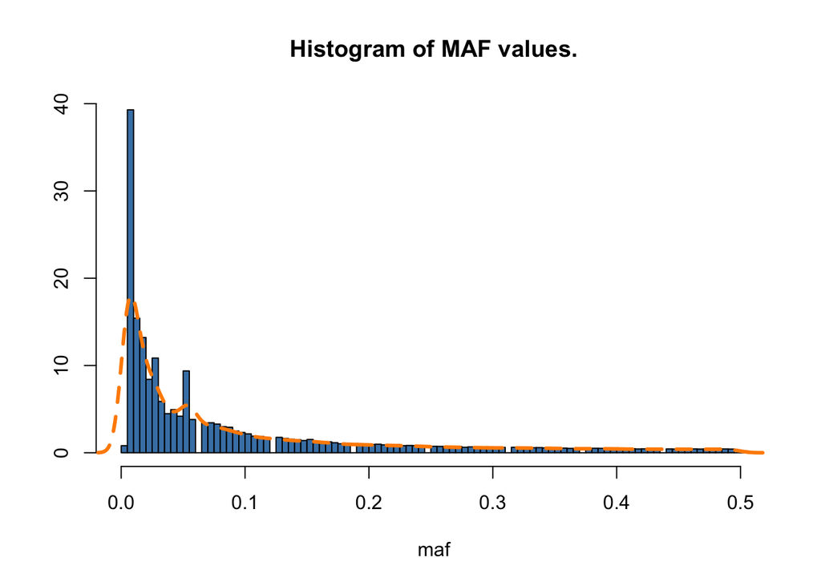

```r
truehist(maf, main = "Histogram of MAF values.", col = "steelblue")
lines(density(maf), lty = 2, col = "darkorange", lwd = 3)
```

### Read only those genotypes with MAF >=0.05

```r
#Read the SNP (MAF>=0.05) data
snp_values = read.table("Desktop/Abhilash/study/Post-Doc/Lab_notebook/eQTL/Input_3/Differential_regulation_files/eQTL_input/MATRIX_eQTL/whole_genome/input/snps_Allchr_maf0.05.txt", sep="\t",
                        header=TRUE, row.names = 1)
```

### Determine the Covariates of SNP data by performing Prinicipal component analysis.

PCs derived from this PCA can be used to adjust for the population startification effects

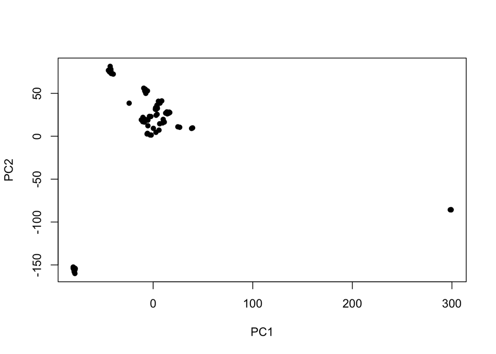

```r
#Obtain the Covarties by PCA of the Genotypes

pca_snps = prcomp(t(snp_values), center=TRUE, scale = F)
plot(pca_snps$x[,c(1,2)],pch=16) # plot the PCA of the SNP data
```

```r
head(pca_snps$x[,c(1,2)])
```

```
##                   PC1         PC2
## FP_CEC3536 -78.603357 -154.908440
## FP_CEC4500 -42.081278   74.409248
## FP_CEC4261   6.552740   14.558466
## FP_CEC3550  39.622969    9.729484
## FP_CEC723   -5.274451   12.204101
## FP_CEC3548  12.554204   26.956526
```

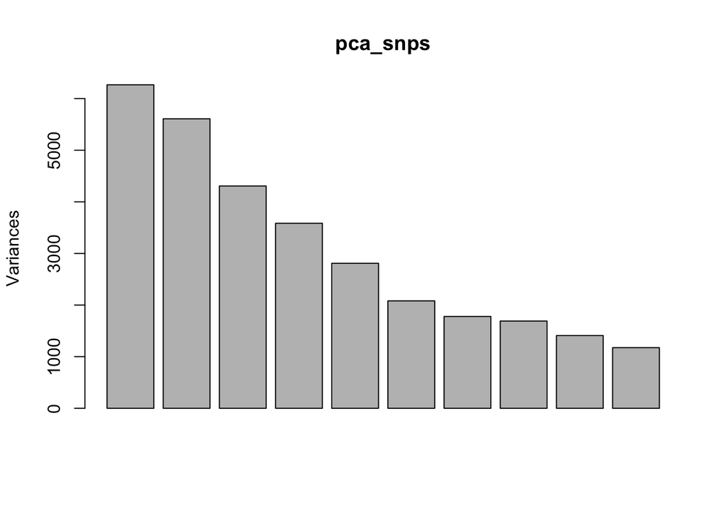

```r
plot(pca_snps)
```

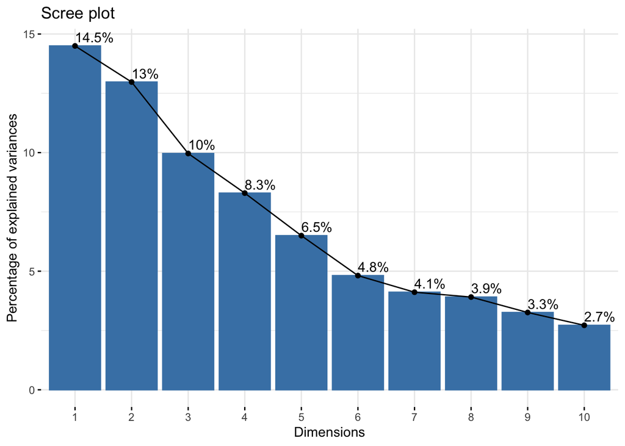

```r
fviz_eig(pca_snps, addlabels = TRUE)
```

```r
#pca_snps$sdev
#summary(pca_snps)
```

### Write the First 10 PCs of the SNP data

```r
# write.csv(pca_snps$x[,1:10],"Desktop/Abhilash/study/Post-Doc/Lab_notebook/eQTL/Input_3/Differential_regulation_files/eQTL_input/MATRIX_eQTL/input/pca_snps.csv")
```

I have commented out the above code, as i have already written this data.

## Step3: Running MatrixEQTL packages: Start of eQTL mapping

### eQTL mapping, cis/trans, with covariate info from PC

#### We begin by reading the Genotypes with MAF >= 0.05 into a data frame

```r
#Read the SNP Genotypes
SNP_file_name <-  "Desktop/Abhilash/study/Post-Doc/Lab_notebook/eQTL/Input_3/Differential_regulation_files/eQTL_input/MATRIX_eQTL/whole_genome/input/snps_Allchr_maf0.05.txt"
```

#### Store the location of the SNPs in a dtaframe.

This dataframe contains the location information of a SNP in the genome

```r
#Read the SNP location data (Where the SNP are located in the Genome)
snps_location_file_name <- "Desktop/Abhilash/study/Post-Doc/Lab_notebook/eQTL/Input_3/Differential_regulation_files/eQTL_input/MATRIX_eQTL/whole_genome/input/snploc_AllChr_maf0.05.txt"
```

#### Store the Batch-corrected normalized Gene Expression data in a dataframe

```r
#Read the Batch-corrected normalized Gene Expression data
expression_file_name <- "Desktop/Abhilash/study/Post-Doc/Lab_notebook/eQTL/Input_3/Differential_regulation_files/eQTL_input/MATRIX_eQTL/whole_genome/input/chrAll_FP_sum_GE.txt"
```

#### Store the Gene location data in a dataframe

This dataframe contains location information of the genes in the genome

```r
#Read the Gene location data (Where the Genes are located in the Genome)
gene_location_file_name <- "Desktop/Abhilash/study/Post-Doc/Lab_notebook/eQTL/Input_3/Differential_regulation_files/eQTL_input/MATRIX_eQTL/whole_genome/input/chrAll_FP_sum_loc.txt"
```

#### Store the covariate data in a dataframe

covariate data contains the first 10 PC’s of the SNP genotypes that will be used to correct population stratification effects

```r
#Read the Covariate data represented by first 10 PCs from the above step
covariates_file_name <- "Desktop/Abhilash/study/Post-Doc/Lab_notebook/eQTL/Input_3/Differential_regulation_files/eQTL_input/MATRIX_eQTL/whole_genome/input/pca_snps_10.txt"
```

#### Setting the p-value thresholds for Cis and Trans eQTLs

Setting the above threshold will identify statistically signinfaction associations from linear regression

```r
cis_threshold <- 1e-5 # P-value threshold for Cis-eQTL identification
trans_threshold <- 1e-5 # P-value threshold for Trans-eQTL identification
cis_dist <- 1e4 # Threshold for Cis distance (+/- 10kb from the TSS)
```

#### Specifying output file names to store the results of the eQTL analysis

```r
# Output file name
#output_file_name_cis = tempfile();
#output_file_name_tra = tempfile();

output_file_name_cis = "Desktop/Abhilash/study/Post-Doc/Lab_notebook/eQTL/Input_3/Differential_regulation_files/eQTL_input/MATRIX_eQTL/whole_genome/output/ten_kb/MAF_0.05/FP/cis/output_AllChr_cis_eqtls_PCA10kb_maf0.05.txt"
output_file_name_tra = "Desktop/Abhilash/study/Post-Doc/Lab_notebook/eQTL/Input_3/Differential_regulation_files/eQTL_input/MATRIX_eQTL/whole_genome/output/ten_kb/MAF_0.05/FP/trans/output_AllChr_trans_eqtls_PCA10kb_maf0.05.txt"
```

#### Specifying other general settings for MatrixEQTL

```r
#Settings
# Linear model to use, modelANOVA, modelLINEAR, or modelLINEAR_CROSS
useModel = modelLINEAR; # modelANOVA, modelLINEAR, or modelLINEAR_CROSS

# Only associations significant at this level will be saved
pvOutputThreshold_cis = cis_threshold;
pvOutputThreshold_tra = trans_threshold;

# Set to character() for no covariates
# covariates_file_name = character();

# Error covariance matrix
# Set to numeric() for identity.
errorCovariance = numeric();

# Distance for local gene-SNP pairs
cisDist = cis_dist

## Load genotype data
snps = SlicedData$new();
snps$fileDelimiter = "\t"; # the TAB character
snps$fileOmitCharacters = "NA"; # denote missing values;
snps$fileSkipRows = 1; # one row of column labels
snps$fileSkipColumns = 1; # one column of row labels
snps$fileSliceSize = 2000; # read file in slices of 2,000 rows
snps$LoadFile(SNP_file_name);


## Load gene expression data
gene = SlicedData$new();
gene$fileDelimiter = "\t"; # the TAB character
gene$fileOmitCharacters = "NA"; # denote missing values;
gene$fileSkipRows = 1; # one row of column labels
gene$fileSkipColumns = 1; # one column of row labels
gene$fileSliceSize = 2000; # read file in slices of 2,000 rows
gene$LoadFile(expression_file_name);

## Load covariates
cvrt = SlicedData$new();
cvrt$fileDelimiter = "\t"; # the TAB character
cvrt$fileOmitCharacters = "NA"; # denote missing values;
cvrt$fileSkipRows = 1; # one row of column labels
cvrt$fileSkipColumns = 1; # one column of row labels
if(length(covariates_file_name)>0) {
  cvrt$LoadFile(covariates_file_name);
}
```

#### Run MatrixEQTL

```r
# Run the analysis
snpspos = read.table(snps_location_file_name, header = TRUE, stringsAsFactors = FALSE);
genepos = read.table(gene_location_file_name, header = TRUE, stringsAsFactors = FALSE);

me_FP = Matrix_eQTL_main(
  snps = snps,
  gene = gene,
  cvrt = cvrt,
  output_file_name = output_file_name_tra,
  pvOutputThreshold = pvOutputThreshold_tra,
  useModel = useModel,
  errorCovariance = errorCovariance,
  verbose = FALSE,
  output_file_name.cis = output_file_name_cis,
  pvOutputThreshold.cis = pvOutputThreshold_cis,
  snpspos = snpspos,
  genepos = genepos,
  cisDist = cisDist,
  pvalue.hist = TRUE,
  min.pv.by.genesnp = FALSE,
  noFDRsaveMemory = FALSE);

#Need to run this to generate Q-Q-plot
me_FP_qq = Matrix_eQTL_main(
  snps = snps,
  gene = gene,
  cvrt = cvrt,
  output_file_name = output_file_name_tra,
  pvOutputThreshold = pvOutputThreshold_tra,
  useModel = useModel,
  errorCovariance = errorCovariance,
  verbose = FALSE,
  output_file_name.cis = output_file_name_cis,
  pvOutputThreshold.cis = pvOutputThreshold_cis,
  snpspos = snpspos,
  genepos = genepos,
  cisDist = cisDist,
  pvalue.hist = "qqplot",
  min.pv.by.genesnp = FALSE,
  noFDRsaveMemory = FALSE)

#unlink(output_file_name_tra);
#unlink(output_file_name_cis);
```

We can check the time taken to finish this analysis

```r
cat('Analysis done in: ', me_FP$time.in.sec, ' seconds', '\n')
```

```
## Analysis done in:  143.645  seconds
```

#### Display first few lines of the result (Cis and Trans-eQTLs ) and generate Q-Q plot

```r
head(me_FP$cis$eqtls)
```

```
##         snps       gene statistic       pvalue          FDR      beta
## 1  Snp_95008 orf19_2285  9.196371 3.613727e-14 4.352749e-08 1.9274461
## 2  Snp_72263 orf19_1527  8.059660 6.179307e-12 1.465056e-06 0.4495702
## 3 Snp_158644 orf19_3362  7.963990 9.513956e-12 1.465056e-06 2.0119201
## 4 Snp_158315 orf19_3362  7.891661 1.318041e-11 1.465056e-06 2.4519927
## 5 Snp_158316 orf19_3362  7.891661 1.318041e-11 1.465056e-06 2.4519927
## 6 Snp_158638 orf19_3362  7.891661 1.318041e-11 1.465056e-06 2.4519927
```

```r
head(me_FP$trans$eqtls)
```

```
##        snps gene statistic       pvalue          FDR      beta
## 1 Snp_69365 ADH3 -15.93828 1.510378e-26 5.864132e-19 -5.917891
## 2 Snp_69490 ADH3 -15.93828 1.510378e-26 5.864132e-19 -5.917891
## 3 Snp_70114 ADH3 -15.93828 1.510378e-26 5.864132e-19 -5.917891
## 4 Snp_70623 ADH3 -15.93828 1.510378e-26 5.864132e-19 -5.917891
## 5 Snp_71042 ADH3 -15.93828 1.510378e-26 5.864132e-19 -5.917891
## 6 Snp_71077 ADH3 -15.93828 1.510378e-26 5.864132e-19 -5.917891
```

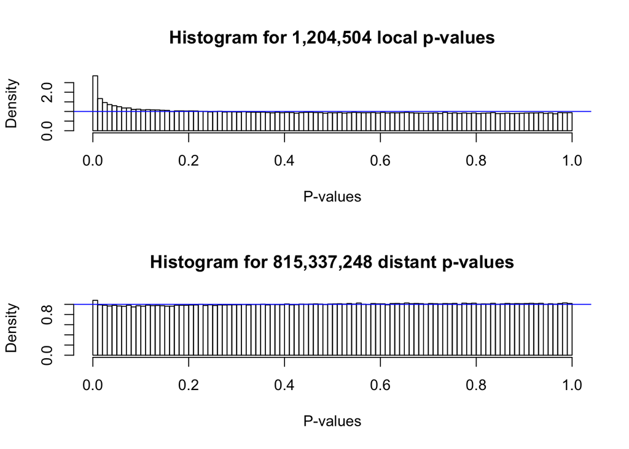

```r
## Make the histogram of local and distant p-values
plot(me_FP)
```

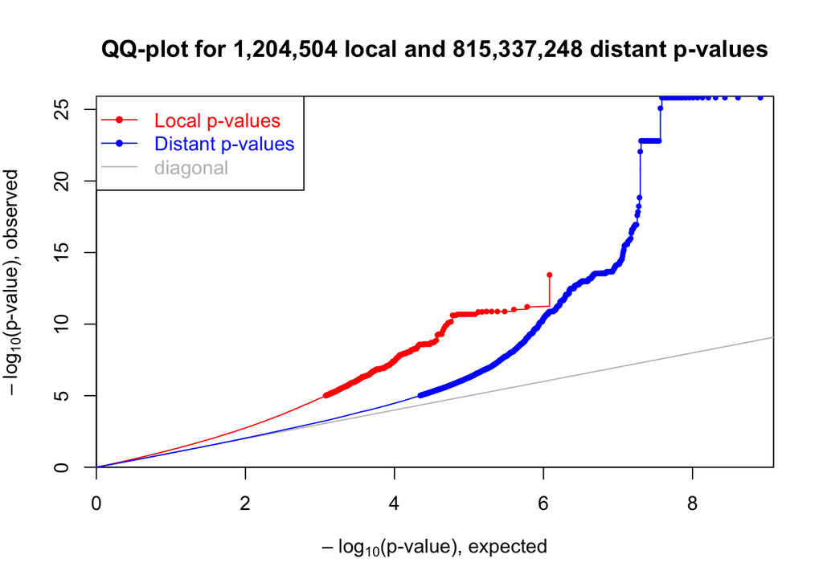

```r
## Make the qq-plot of local and distant p-values
plot(me_FP_qq)
```

## Step 4: Extract the top cis-eQTLs from the Monoculture data

We once again need to the SNp and Gene expression data into a new dataframe. It is important to transpose both these dataframes and finally extract the top cis-eQTLs from the analysis.

```r
#Reading the SNP data to a new variable 'snp_values'
snp_values = read.table(SNP_file_name, row.names=1, header=TRUE)
snp_values = data.frame(snps = rownames(snp_values), snp_values, stringsAsFactors = FALSE)
snp_values=snp_values[,-c(1)]

# We also create a dataframe with expression data
gene_values = read.table(expression_file_name, row.names=1, header=TRUE)
gene_values = data.frame(gene = rownames(gene_values), gene_values, stringsAsFactors = FALSE)
gene_values=gene_values[,-c(1)]
#View(gene_values)

#create transposed dataframe
gene_values_transpose <- as.data.frame(as.matrix(t(gene_values)))
snp_values_transpose <- as.data.frame(as.matrix(t(snp_values)))
```

```r
#Extract the top cis-eQTLs from the Monoculture data

cis_eqtl_FP_res = me_FP$cis$eqtls
cis_eqtl_FP_res = cis_eqtl_FP_res[cis_eqtl_FP_res$FDR < 0.05,]
top_cis_eqtls_FP = cis_eqtl_FP_res[order(cis_eqtl_FP_res$pvalue),]
top_cis_eqtls_FP = top_cis_eqtls_FP[!duplicated(top_cis_eqtls_FP$gene),]
mafs = apply(as.matrix(snp_values[-1]),1,mean)/2
mafs = pmin(mafs, 1 - mafs)
mafs = data.frame(snps=names(mafs), maf = mafs)
top_cis_eqtls_FP = merge(top_cis_eqtls_FP, mafs, by="snps")
top_cis_eqtls_FP = top_cis_eqtls_FP[order(top_cis_eqtls_FP$FDR),]
head(top_cis_eqtls_FP)
```

```
##           snps       gene statistic       pvalue          FDR       beta
## 278  Snp_95008 orf19_2285  9.196371 3.613727e-14 4.352749e-08  1.9274461
## 26  Snp_119672       SAP8  7.877280 1.406247e-11 1.465056e-06  2.9146593
## 65  Snp_158644 orf19_3362  7.963990 9.513956e-12 1.465056e-06  2.0119201
## 101 Snp_197430 orf19_6681  7.791637 2.067736e-11 1.465056e-06  0.7129388
## 252  Snp_72263 orf19_1527  8.059660 6.179307e-12 1.465056e-06  0.4495702
## 41  Snp_142071 orf19_6777 -7.755437 2.433379e-11 1.465507e-06 -1.1808926
##            maf
## 278 0.09890110
## 26  0.06593407
## 65  0.06593407
## 101 0.09890110
## 252 0.08791209
## 41  0.09340659
```

```r
#write.table(top_cis_eqtls_FP, "Desktop/Abhilash/study/Post-Doc/Lab_notebook/eQTL/Input_3/Differential_regulation_files/eQTL_input/MATRIX_eQTL/whole_genome/output/top_cis_eQTL_FP_10kb_maf0.05.txt", sep = "\t")
```

## Step 5: Extract the top trans-eQTLs from the Monoculture data

Before running this run cis eQTL analysis for FP (monoculture)

```r
#Before running this run cis eQTL analysis for FP (monoculture)

trans_eqtl_FP_res = me_FP$trans$eqtls
trans_eqtl_FP_res = trans_eqtl_FP_res[trans_eqtl_FP_res$FDR < 0.05,]
top_trans_eqtls_FP = trans_eqtl_FP_res[order(trans_eqtl_FP_res$pvalue),]
top_trans_eqtls_FP = top_trans_eqtls_FP[!duplicated(top_trans_eqtls_FP$gene),]
mafs = apply(as.matrix(snp_values[-1]),1,mean)/2
mafs = pmin(mafs, 1 - mafs)
mafs = data.frame(snps=names(mafs), maf = mafs)
top_trans_eqtls_FP = merge(top_trans_eqtls_FP, mafs, by="snps")
top_trans_eqtls_FP = top_trans_eqtls_FP[order(top_trans_eqtls_FP$FDR),]
head(top_trans_eqtls_FP)
```

```
##           snps       gene  statistic       pvalue          FDR      beta
## 518  Snp_69365       ADH3 -15.938277 1.510378e-26 5.864132e-19 -5.917891
## 451  Snp_44048       NIT2 -11.468541 1.438729e-18 2.666021e-11 -7.056050
## 489  Snp_58513 orf19_7545 -10.934752 1.502082e-17 2.499394e-10 -8.811139
## 577  Snp_97530      MNN14 -10.398628 1.624046e-16 2.244314e-09 -3.853488
## 84  Snp_124780      SAP98  -9.683643 4.007695e-15 4.299504e-08 -3.720077
## 25  Snp_106056       SMP3   9.524766 8.201209e-15 7.598581e-08  3.712424
##            maf
## 518 0.08791209
## 451 0.06043956
## 489 0.06043956
## 577 0.12087912
## 84  0.08241758
## 25  0.10989011
```

```r
#write.table(top_trans_eqtls_FP, "Desktop/Abhilash/study/Post-Doc/Lab_notebook/eQTL/Input_3/Differential_regulation_files/eQTL_input/MATRIX_eQTL/whole_genome/output/ten_kb/MAF_0.05/FP/trans/top_trans_eQTL_FP_10kb_maf0.05.txt", sep = "\t")
```